# Abalone Report

Data exploration, Cleaning, Models and Tests

Melinda Higgins

09/06/2023

## Summary Statistics of Abalones’ - Dimensional Measurements

A useful R package for making tables is the `arsenal` package. Learn more at:

- https://cran.r-project.org/web/packages/arsenal/index.html and
- https://mayoverse.github.io/arsenal/.

The key function is `tableby()`, see the vignette at https://mayoverse.github.io/arsenal/articles/tableby.html.

|  | Overall (N=4169) |
| --- | --- |
| **length** |  |
| Mean (SD) | 0.524 (0.120) |
| Range | 0.075 - 0.815 |
| **diameter** |  |
| Mean (SD) | 0.408 (0.099) |
| Range | 0.055 - 0.650 |
| **height** |  |
| Mean (SD) | 0.139 (0.039) |
| Range | 0.010 - 0.515 |

## Summary Statistics of Abalones’ - Weight Measurements

|  | Overall (N=4169) |
| --- | --- |
| **wholeWeight** |  |
| Mean (SD) | 0.830 (0.490) |
| Range | 0.002 - 2.825 |
| **shuckedWeight** |  |
| Mean (SD) | 0.360 (0.222) |
| Range | 0.001 - 1.488 |
| **visceraWeight** |  |
| Mean (SD) | 0.181 (0.110) |
| Range | 0.000 - 0.760 |
| **shellWeight** |  |
| Mean (SD) | 0.239 (0.139) |
| Range | 0.002 - 1.005 |

## Abalone Dimensional Measurements by Sex - default statistical tests

Now we can add a grouping variable such as comparing these summary statistics between the 3 biological sex groups: Male, Female and Infant.

Notice that the default settings produce a p-value. The `arsenal::tableby()` function is performing an ANOVA (analysis of variance) for each of these measurements.

|  | F (N=1306) | I (N=1335) | M (N=1528) | Total (N=4169) | p value |
| --- | --- | --- | --- | --- | --- |
| **length** |  |  |  |  | < 0.001<sup>1</sup> |
| Mean (SD) | 0.579 (0.086) | 0.428 (0.109) | 0.561 (0.103) | 0.524 (0.120) |  |
| Range | 0.275 - 0.815 | 0.075 - 0.725 | 0.155 - 0.780 | 0.075 - 0.815 |  |
| **diameter** |  |  |  |  | < 0.001<sup>1</sup> |
| Mean (SD) | 0.455 (0.071) | 0.327 (0.088) | 0.439 (0.084) | 0.408 (0.099) |  |
| Range | 0.195 - 0.650 | 0.055 - 0.550 | 0.110 - 0.630 | 0.055 - 0.650 |  |
| **height** |  |  |  |  | < 0.001<sup>1</sup> |
| Mean (SD) | 0.157 (0.030) | 0.108 (0.032) | 0.151 (0.035) | 0.139 (0.039) |  |
| Range | 0.015 - 0.250 | 0.010 - 0.220 | 0.025 - 0.515 | 0.010 - 0.515 |  |

1. Linear Model ANOVA

## Abalone Dimensional Measurements by Sex - change statistical test

Suppose you decide that `diameter` is skewed and really need non-parametric statistics and the Kruskall-Wallis non-parametric ANOVA test performed. We can customize the statistics - learn more at https://mayoverse.github.io/arsenal/articles/tableby.html#change-summary-statistics-within-the-formula-1 and see more options at https://mayoverse.github.io/arsenal/articles/tableby.html#available-function-options-1.

You’ll notice this automatically creates footnotes for each customized statistic in the output table.

|  | F (N=1306) | I (N=1335) | M (N=1528) | Total (N=4169) | p value |
| --- | --- | --- | --- | --- | --- |
| **length** |  |  |  |  | < 0.001<sup>1</sup> |
| Mean (SD) | 0.579 (0.086) | 0.428 (0.109) | 0.561 (0.103) | 0.524 (0.120) |  |
| **diameter** |  |  |  |  | < 0.001<sup>2</sup> |
| Median (Q1, Q3) | 0.465 (0.410, 0.505) | 0.335 (0.270, 0.395) | 0.455 (0.395, 0.500) | 0.425 (0.350, 0.480) |  |
| **height** |  |  |  |  | < 0.001<sup>1</sup> |
| Mean (SD) | 0.157 (0.030) | 0.108 (0.032) | 0.151 (0.035) | 0.139 (0.039) |  |

1. Linear Model ANOVA
2. Kruskal-Wallis rank sum test

## Abalone Weight Measurements by Sex

|  | F (N=1306) | I (N=1335) | M (N=1528) | Total (N=4169) | p value |
| --- | --- | --- | --- | --- | --- |
| **wholeWeight** |  |  |  |  | < 0.001<sup>1</sup> |
| Mean (SD) | 1.047 (0.430) | 0.432 (0.286) | 0.991 (0.471) | 0.830 (0.490) |  |
| Range | 0.080 - 2.657 | 0.002 - 2.050 | 0.015 - 2.825 | 0.002 - 2.825 |  |
| **shuckedWeight** |  |  |  |  | < 0.001<sup>1</sup> |
| Mean (SD) | 0.446 (0.199) | 0.191 (0.128) | 0.433 (0.223) | 0.360 (0.222) |  |
| Range | 0.031 - 1.488 | 0.001 - 0.773 | 0.006 - 1.351 | 0.001 - 1.488 |  |
| **visceraWeight** |  |  |  |  | < 0.001<sup>1</sup> |
| Mean (SD) | 0.231 (0.098) | 0.092 (0.063) | 0.216 (0.105) | 0.181 (0.110) |  |
| Range | 0.021 - 0.590 | 0.000 - 0.440 | 0.003 - 0.760 | 0.000 - 0.760 |  |
| **shellWeight** |  |  |  |  | < 0.001<sup>1</sup> |
| Mean (SD) | 0.302 (0.126) | 0.128 (0.085) | 0.282 (0.131) | 0.239 (0.139) |  |
| Range | 0.025 - 1.005 | 0.002 - 0.655 | 0.005 - 0.897 | 0.002 - 1.005 |  |

1. Linear Model ANOVA

## Plot of Abalone Age by shuckedWeight

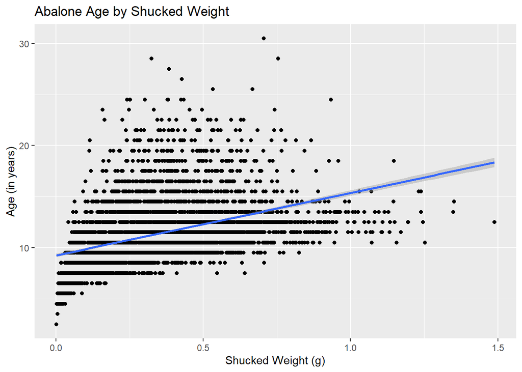

## Plot of Abalone Age by Shucked Weight - by sex

Create a plot of abalone age by shucked weight in g Show the plot by sex - either add a color by sex or a facet_wrap().

[figure not shown]

[figure not shown]

## Linear Regression - Abalone Age by Shucked Weight (model 1)

Regression of Abalone Age by Shucked Weight

| term | estimate | std.error | statistic | p.value |
| --- | --- | --- | --- | --- |
| (Intercept) | 9.243295 | 0.0861858 | 107.24850 | 0 |
| shuckedWeight | 6.110826 | 0.2039592 | 29.96102 | 0 |

## Linear Regression - Abalone Age by Shucked Weight, adjusted for sex (model 2)

Regression of Abalone Age by Shucked Weight adjusted for Sex

| term | estimate | std.error | statistic | p.value |
| --- | --- | --- | --- | --- |
| (Intercept) | 10.9143080 | 0.1285277 | 84.917946 | 0.0000000 |
| shuckedWeight | 3.8482792 | 0.2295312 | 16.765820 | 0.0000000 |
| sexI | -2.2489742 | 0.1239592 | -18.142855 | 0.0000000 |
| sexM | -0.3749078 | 0.1057687 | -3.544601 | 0.0003975 |

## Compare Models - piecemeal steps

The change in R2 for the 2 models is 0.0657824 with a p-value of 4.3055706^{-76}.

# Compare models - use `gtsummary` package

Model 1 output

| **Characteristic** | **Beta** | **95% CI**<sup>1</sup> | **p-value** |
| --- | --- | --- | --- |
| (Intercept) | 9.2 | 9.1, 9.4 | <0.001 |
| shuckedWeight | 6.1 | 5.7, 6.5 | <0.001 |

<sup>1</sup> CI = Confidence Interval

Model 2 output

| **Characteristic** | **Beta** | **95% CI**<sup>1</sup> | **p-value** |
| --- | --- | --- | --- |
| (Intercept) | 11 | 11, 11 | <0.001 |
| shuckedWeight | 3.8 | 3.4, 4.3 | <0.001 |
| sex |  |  |  |
| F | — | — |  |
| I | -2.2 | -2.5, -2.0 | <0.001 |
| M | -0.37 | -0.58, -0.17 | <0.001 |

<sup>1</sup> CI = Confidence Interval

Put models side by side

| **Characteristic** | **Model 1** **Beta** | **Model 1** **95% CI**<sup>1</sup> | **Model 1** **p-value** | **Model 2** **Beta** | **Model 2** **95% CI**<sup>1</sup> | **Model 2** **p-value** |
| --- | --- | --- | --- | --- | --- | --- |
| (Intercept) | 9.2 | 9.1, 9.4 | <0.001 | 11 | 11, 11 | <0.001 |
| shuckedWeight | 6.1 | 5.7, 6.5 | <0.001 | 3.8 | 3.4, 4.3 | <0.001 |
| sex |  |  |  |  |  |  |
| F |  |  |  | — | — |  |
| I |  |  |  | -2.2 | -2.5, -2.0 | <0.001 |
| M |  |  |  | -0.37 | -0.58, -0.17 | <0.001 |

<sup>1</sup> CI = Confidence Interval

## The `stargazer` package - works for HTML and PDF

**WARNING** This does NOT work for WORD documents. However, you can create the HTML output and then “cut-and-paste” the HTML table into WORD.

## Creating APA style tables

This package makes nice output but saves each table in a separate output DOC file. This does work for WORD documents.

To embed the `apaTable` output inside the Rmarkdown document, we can do the following…

Pull out the key parts of the output object. Make a nice table for the formatted output for `apa3` and then add the footnote using inline r code.

| Predictor | b | b_95%_CI | sr2 | sr2_95%_CI | Fit | Difference |
| --- | --- | --- | --- | --- | --- | --- |
| (Intercept) | 9.24** | [9.07, 9.41] |  |  |  |  |
| shuckedWeight | 6.11** | [5.71, 6.51] | .18 | [.16, .20] |  |  |
|  |  |  |  |  | R2 = .177** |  |
|  |  |  |  |  | 95% CI[.16,.20] |  |
| (Intercept) | 10.91** | [10.66, 11.17] |  |  |  |  |
| shuckedWeight | 3.85** | [3.40, 4.30] | .05 | [.04, .06] |  |  |
| sexI | -2.25** | [-2.49, -2.01] | .06 | [.05, .07] |  |  |
| sexM | -0.37** | [-0.58, -0.17] | .00 | [-.00, .00] |  |  |
|  |  |  |  |  | R2 = .243** | Delta R2 = .066** |
|  |  |  |  |  | 95% CI[.22,.26] | 95% CI[.05, .08] |

Note. A significant b-weight indicates the beta-weight and semi-partial correlation are also significant. b represents unstandardized regression weights. beta indicates the standardized regression weights. sr2 represents the semi-partial correlation squared. r represents the zero-order correlation. Square brackets are used to enclose the lower and upper limits of a confidence interval. * indicates p < .05. ** indicates p < .01.

## Visualize Regression Coefficients

Here is an example plot of the coefficients from Model 2 (`lm2`) using the packages from `easystats` - namely the `parameters` and `see` packages.

Learn more at https://easystats.github.io/easystats/.

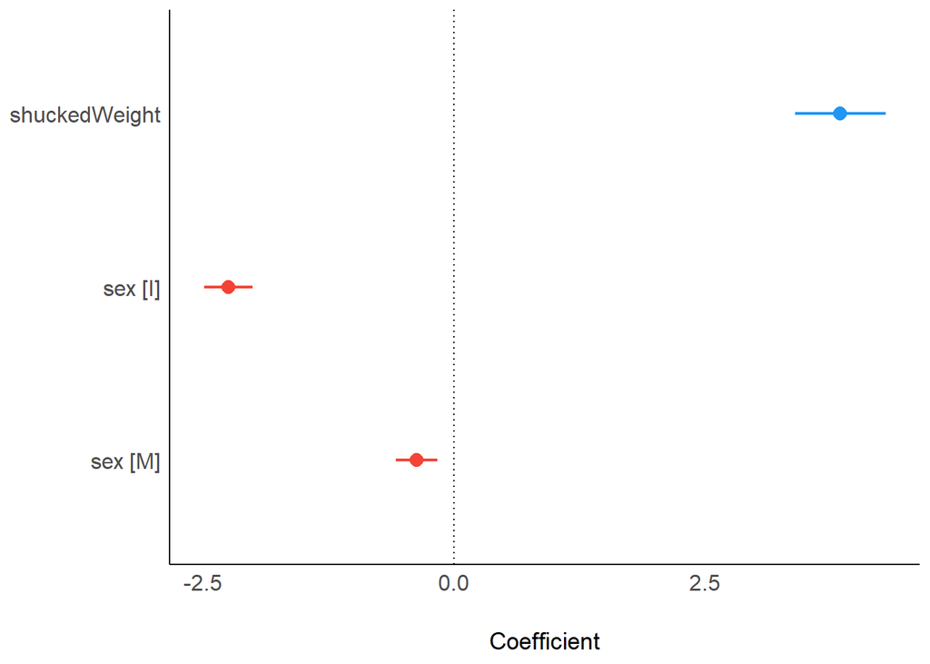

Here is another example using the `sjPlot` package. Note: I also had to install/update the associated `sjstats` package. Learn more at http://www.strengejacke.de/sjPlot/reference/plot_model.html.

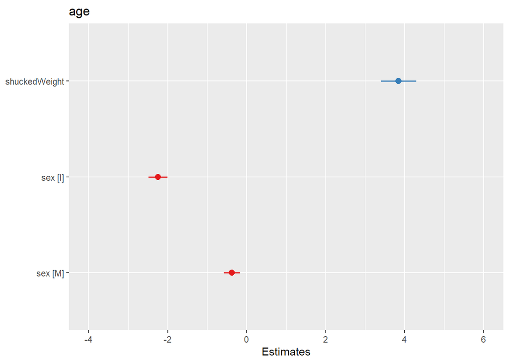

## Logistic Regression of `adult` by Shucked Weight and Diameter

**NOTE:** The `adult` variable is currently a “character” class variable. So, let’s create a 0/1 coded variable.

Use `parameters` package to get model coefficients table.

| Parameter | Coefficient | SE | CI | CI_low | CI_high | z | df_error | p |
| --- | --- | --- | --- | --- | --- | --- | --- | --- |
| (Intercept) | 0.0365486 | 0.0110825 | 0.95 | 0.0200387 | 0.0657934 | -10.913014 | Inf | 0e+00 |
| shuckedWeight | 217.0126805 | 139.5074649 | 0.95 | 62.5988462 | 778.3652734 | 8.368861 | Inf | 0e+00 |
| diameter | 540.2870048 | 637.2057215 | 0.95 | 53.9313991 | 5495.9308663 | 5.335075 | Inf | 1e-07 |

Another option using the `gtsummary` package.

| **Characteristic** | **OR**<sup>1</sup> | **95% CI**<sup>1</sup> | **p-value** |
| --- | --- | --- | --- |
| shuckedWeight | 217 | 62.6, 778 | <0.001 |
| diameter | 540 | 53.9, 5,496 | <0.001 |

<sup>1</sup> OR = Odds Ratio, CI = Confidence Interval

Compute the AUC for the model and plot the ROC curve.

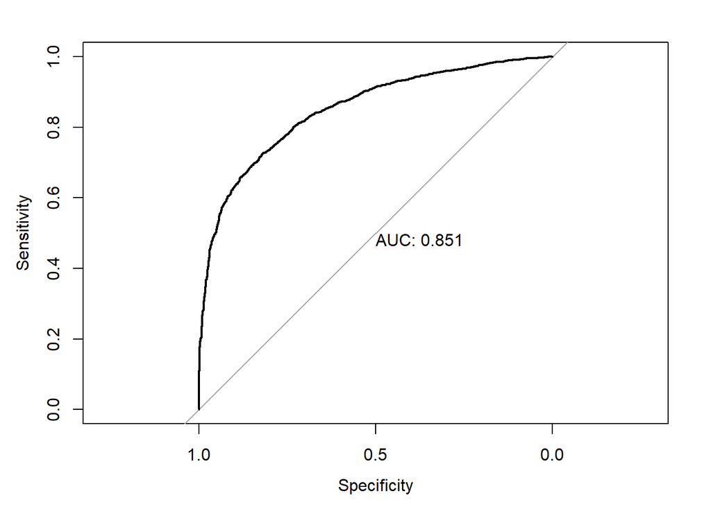

```
##
## Call:
## roc.formula(formula = abalone$adult01 ~ pred_glm1, plot = TRUE,     print.auc = TRUE)
##
## Data: pred_glm1 in 1335 controls (abalone$adult01 0) < 2834 cases (abalone$adult01 1).
## Area under the curve: 0.8507
```